# Análise sobre vinhos tintos e quais propriedades químicas influenciam a qualidade por Maycon Pinheiro Queiros

# Seção de Gráficos Univariados

```
## [1] 1599   12
```

O conjunto de dados é composto por 12 variáveis com 1599 observações.

```
## 'data.frame':    1599 obs. of  12 variables:
##  $ fixed.acidity       : num  7.4 7.8 7.8 11.2 7.4 7.4 7.9 7.3 7.8 7.5 ...
##  $ volatile.acidity    : num  0.7 0.88 0.76 0.28 0.7 0.66 0.6 0.65 0.58 0.5 ...
##  $ citric.acid         : num  0 0 0.04 0.56 0 0 0.06 0 0.02 0.36 ...
##  $ residual.sugar      : num  1.9 2.6 2.3 1.9 1.9 1.8 1.6 1.2 2 6.1 ...
##  $ chlorides           : num  0.076 0.098 0.092 0.075 0.076 0.075 0.069 0.065 0.073 0.071 ...
##  $ free.sulfur.dioxide : num  11 25 15 17 11 13 15 15 9 17 ...
##  $ total.sulfur.dioxide: num  34 67 54 60 34 40 59 21 18 102 ...
##  $ density             : num  0.998 0.997 0.997 0.998 0.998 ...
##  $ pH                  : num  3.51 3.2 3.26 3.16 3.51 3.51 3.3 3.39 3.36 3.35 ...
##  $ sulphates           : num  0.56 0.68 0.65 0.58 0.56 0.56 0.46 0.47 0.57 0.8 ...
##  $ alcohol             : num  9.4 9.8 9.8 9.8 9.4 9.4 9.4 10 9.5 10.5 ...
##  $ quality             : int  5 5 5 6 5 5 5 7 7 5 ...
```

Todas são variáveis númericas, sendo “quality” a única com valores inteiros e as outras são do tipo ponto flutuante.

```
##  fixed.acidity   volatile.acidity  citric.acid    residual.sugar
##  Min.   : 4.60   Min.   :0.1200   Min.   :0.000   Min.   : 0.900
##  1st Qu.: 7.10   1st Qu.:0.3900   1st Qu.:0.090   1st Qu.: 1.900
##  Median : 7.90   Median :0.5200   Median :0.260   Median : 2.200
##  Mean   : 8.32   Mean   :0.5278   Mean   :0.271   Mean   : 2.539
##  3rd Qu.: 9.20   3rd Qu.:0.6400   3rd Qu.:0.420   3rd Qu.: 2.600
##  Max.   :15.90   Max.   :1.5800   Max.   :1.000   Max.   :15.500
##    chlorides       free.sulfur.dioxide total.sulfur.dioxide
##  Min.   :0.01200   Min.   : 1.00       Min.   :  6.00
##  1st Qu.:0.07000   1st Qu.: 7.00       1st Qu.: 22.00
##  Median :0.07900   Median :14.00       Median : 38.00
##  Mean   :0.08747   Mean   :15.87       Mean   : 46.47
##  3rd Qu.:0.09000   3rd Qu.:21.00       3rd Qu.: 62.00
##  Max.   :0.61100   Max.   :72.00       Max.   :289.00
##     density             pH          sulphates         alcohol
##  Min.   :0.9901   Min.   :2.740   Min.   :0.3300   Min.   : 8.40
##  1st Qu.:0.9956   1st Qu.:3.210   1st Qu.:0.5500   1st Qu.: 9.50
##  Median :0.9968   Median :3.310   Median :0.6200   Median :10.20
##  Mean   :0.9967   Mean   :3.311   Mean   :0.6581   Mean   :10.42
##  3rd Qu.:0.9978   3rd Qu.:3.400   3rd Qu.:0.7300   3rd Qu.:11.10
##  Max.   :1.0037   Max.   :4.010   Max.   :2.0000   Max.   :14.90
##     quality
##  Min.   :3.000
##  1st Qu.:5.000
##  Median :6.000
##  Mean   :5.636
##  3rd Qu.:6.000
##  Max.   :8.000
```

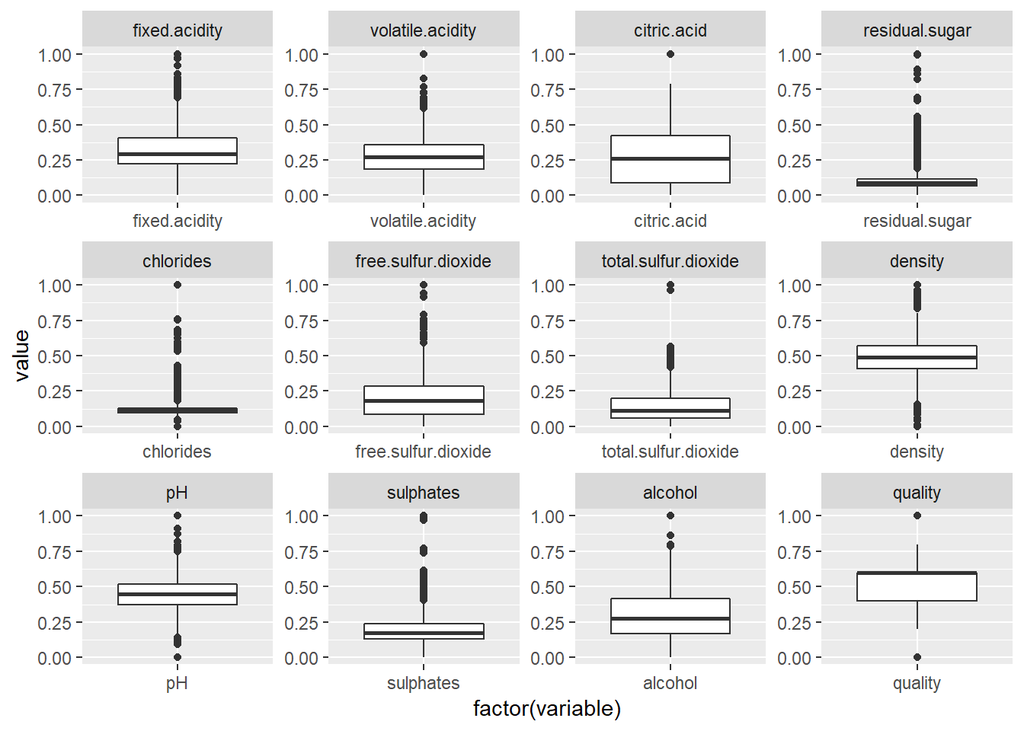

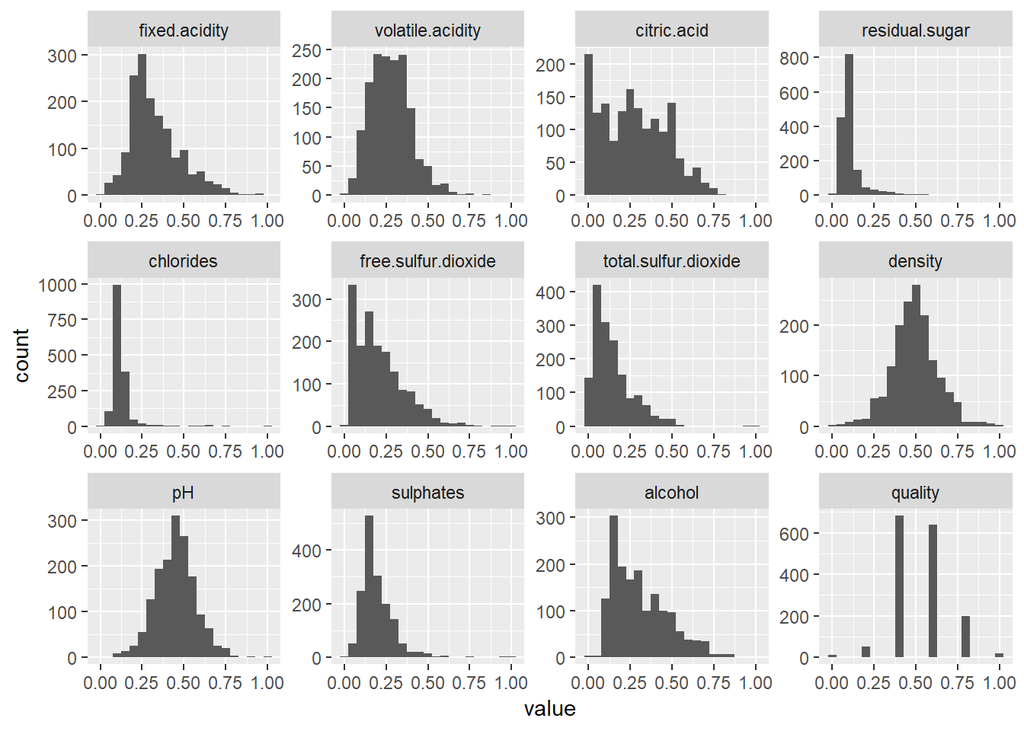

Primeiramente, analisarei a estrutura geral e distribuição de cada variável. Para gerar os gráficos, apliquei uma normalização nas variáveis para que os valores fiquem todos na mesma escala com valores entre 0 e 1 (técnica chamada de *min-max normalization*).

Observando os boxplots, podemos ver que muitas das variáveis apresentam outliers, por exemplo, as variáveis *residual.sugar*, *chlorides* e *sulphates*. A variável *density* tem um comportamento interessante, a amplitude dos valores é bem pequena, concentrados em uma pequena faixa de valores, algo similar aconcete com a variável *sulphates*, os valores estão concentrados em uma pequena faixa, porém temos outliers que estão bem acima da média/mediana.

Observando os histogramas, é possível ver de início algumas variáveis com distribuições normais ou próximas disso, sendo elas *fixed.acidity*, *volatile.acidity*, *pH*, *density* e *quality*.

Outras variáveis tem uma visível distribuição distorcida à direita, como *citric.acid* e *alcohol*. AS variáveis *residual.sugar* e *chlorides* também aparentam isso, mas pode ser devido aos outliers presentes mais à direita dos gráficos.

Agora vamos observar com mais detalhes algumas das variáveis.

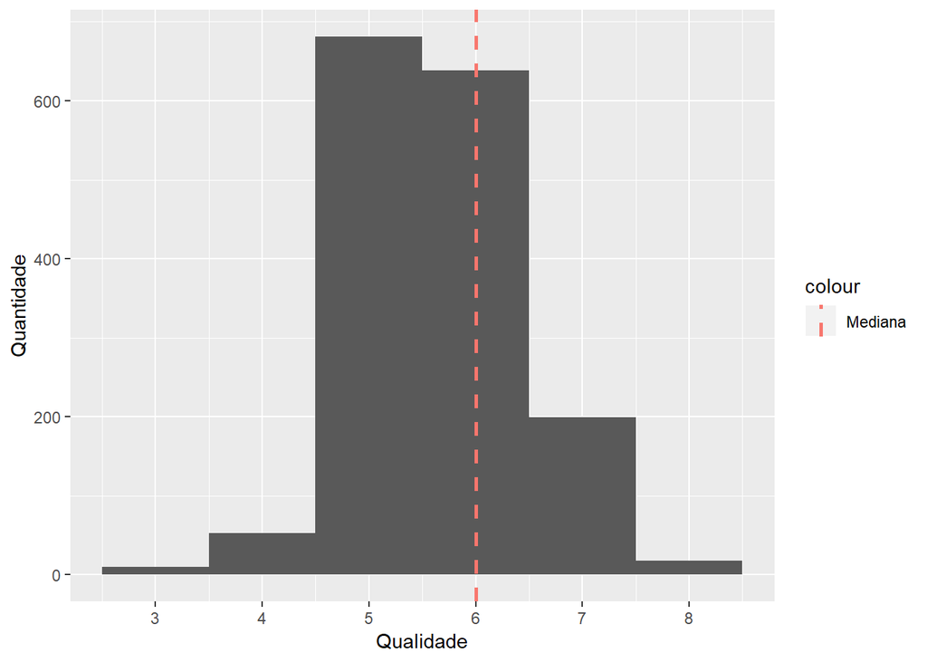

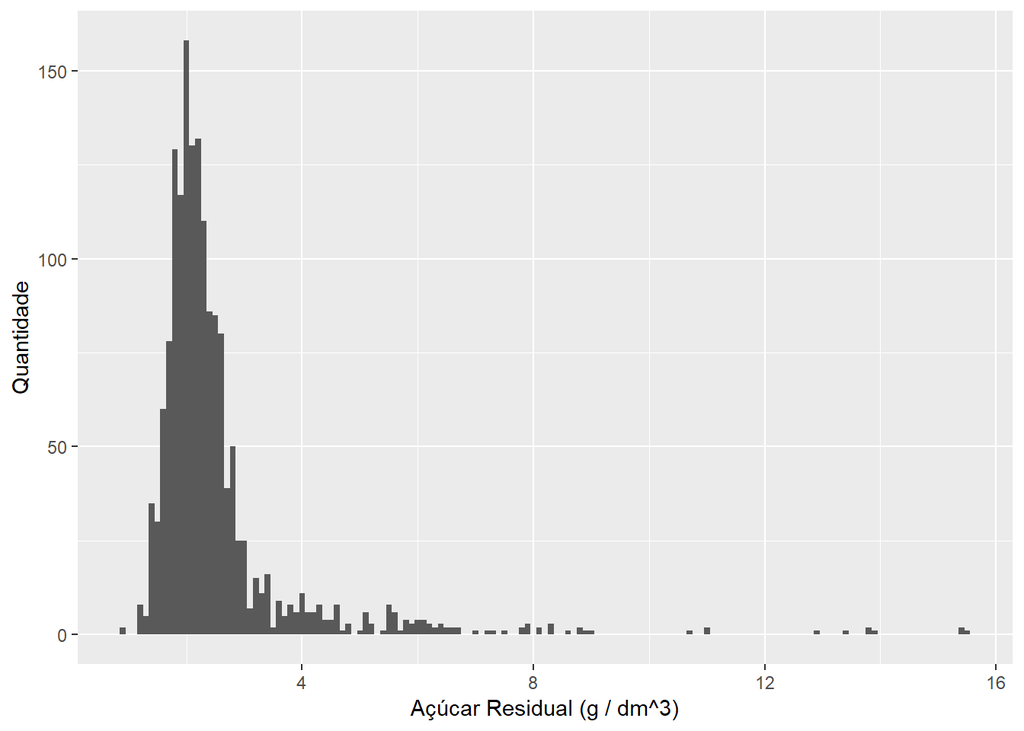

Como vimos anteriormente, há uma distorção a direita no histograma de *residual.sugar* (quanto mais alto o valor desta variável, mais doce é o vinho), talvez ao remover valores extremos, estaremos mais próximos de uma distribuição normal.

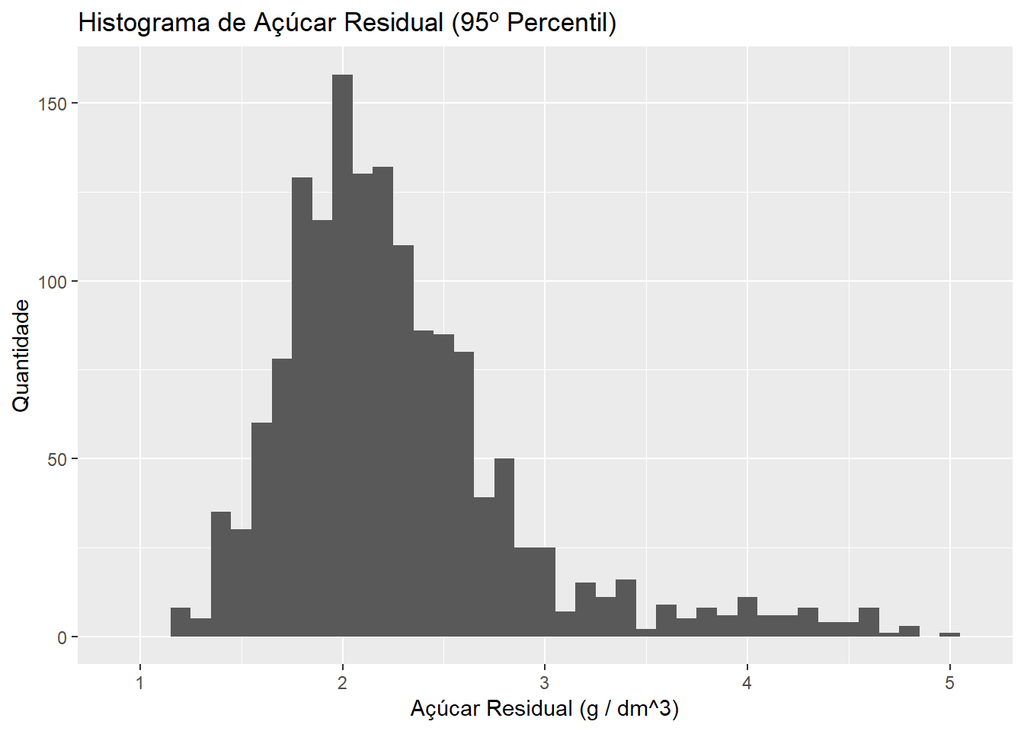

O gráfico acima é um zoom considerando apenas as observações dentro do 95º percentil da variável *residual.sugar*, vemos que ainda há uma distorção significativa à direita.

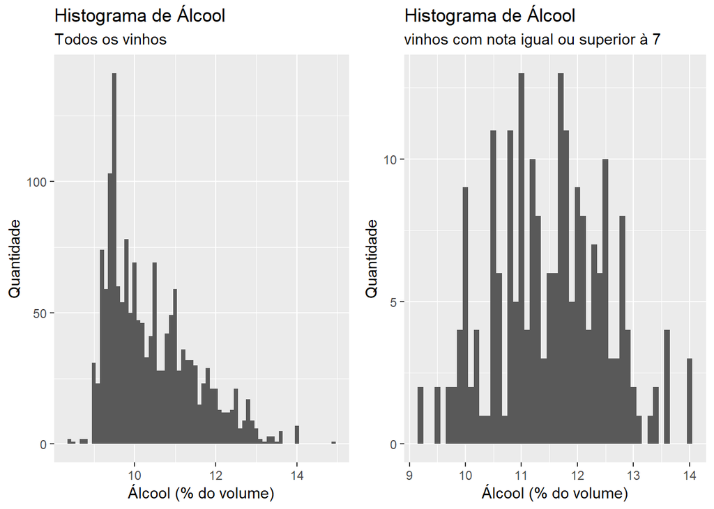

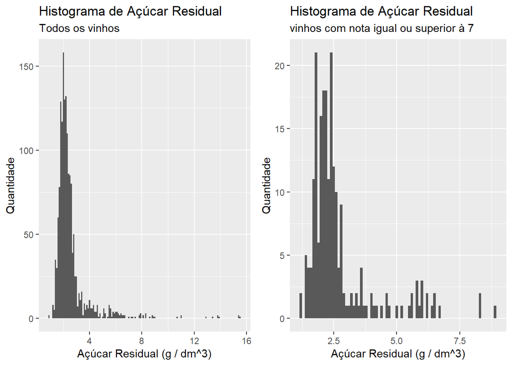

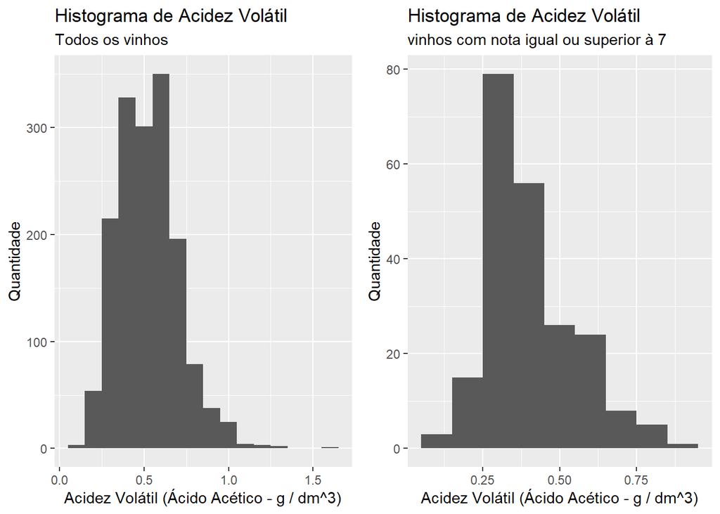

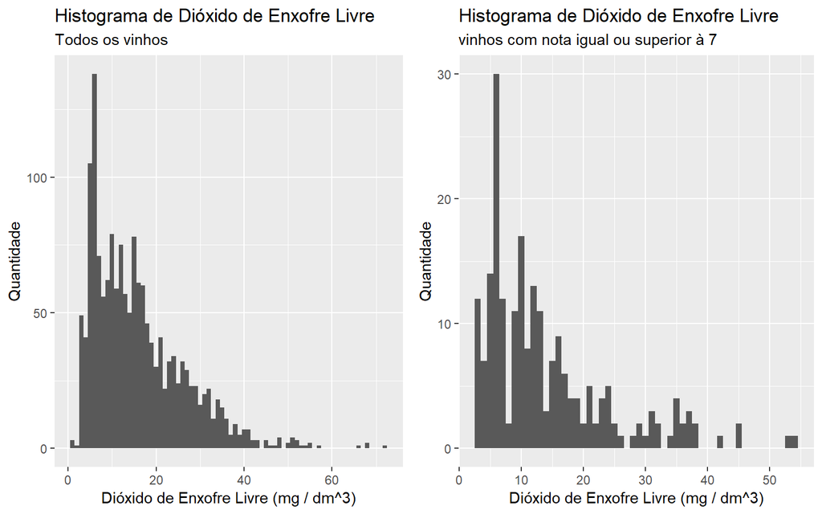

Vejamos algumas características segmentando vinhos de qualidade igual ou superior à 7 e como eles se comparam aos vinhos no geral. Observamos as variáveis *alcohol*, *residual.sugar*, *volatile.acidity* e *free.sulfur.dioxide*. Ao que parece, o álcool influencia mais na qualidade quando em valores mais extremos tanto para cima quando para baixo, os vinhos de alta qualidade apresentam uma distribuição um pouco mais uniforme. Já com relação ao açúcar, vinhos mais doces foram considerados inferiores. A acidez volátil parece interferir em níveis mais altos assim como dióxide de enxofre.

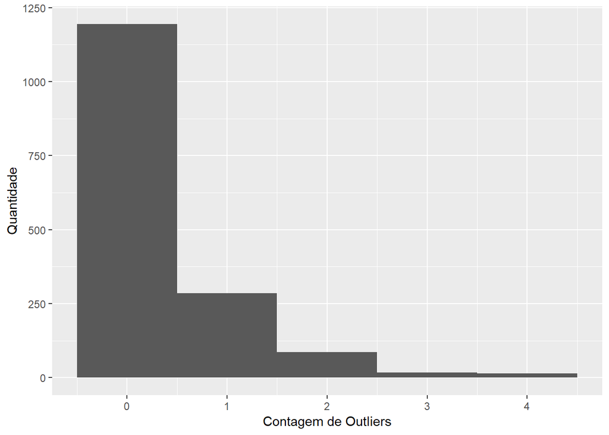

Por fim, vamos detectar se existem muitos outliers dentre as variáveis analisadas, utilizei o método *Turkey’s fences* para determinar se uma observação de uma das variáveis é ou não um outlier. Também criei uma variável que indica a contagem de variáveis de um vinho que foram identificadas como outliers

O gráfico acima aponta a quantidade de vinhos de acordo com quantas variáveis com valores aberrantes ele possui. Vemos que a grande maioria não apresenta nenhuma variável outlier, observaremos mais adiante se há uma correlação entre a contagem de outliers e a qualidade do vinho.

# Análise Univariada

### Qual é a estrutura do conjunto de dados?

O conjunto de dados analisado é composto por 12 variáveis com 1599 observações.

Todas são variáveis númericas, sendo “quality” a única com valores inteiros e as outras são do tipo ponto flutuante.

### Quais são os principais atributos de interesse deste conjunto de dados?

A variável *quality* será muito importante, ela servirá de variável dependente em que iremos avaliar como as outras variáveis interferem nela. Ela varia numa escala de 0 a 10 e é interessante ver que não há vinhos com qualidade inferior a 3 ou superior a 8.

A variável *density* possui uma amplitude de valores muito baixa. Outras já tem amplitudes maiores como *free.sulfur.dioxide* e *total.sulfur.dioxide*

O nível de açúcar, o teor alcoólico paracem ser relevantes para determinar a qualidade.

### Quais outros atributos você acha que podem lhe auxiliar na investigação destes atributos de interesse?

Além disso, a acidez volátil (contribui para o aroma de vinagre) e o equilíbrio das características do vinho também deve ser importante, se alguma propriedade se sobresai demais, ela pode interferir na qualidade [1].

O volume de dióxido de enxofre parece interferir na qualidade quando em grande quantidade.

Fontes: [1]https://www.clubedosvinhos.com.br/qualidade-de-um-vinho/

### Você criou novas variáveis a partir dos atributos existentes no conjunto de dados?

Sim, criei novas variáveis para cada uma das variáveis com excessão de *quality* para indicar se o valor observado é ou não um outlier.

Também criei outra variável que indica a quantidade de variáveis com valores aberrantes para o vinho observado.

### Dos atributos investigados, distribuições incomuns foram encontradas? Você aplicou operações nos dados para limpá-los, ajustá-los ou mudar a forma dos dados? Se sim, por quê?

Os atributos com comportamento mais incomuns foram *residual.sugar* e *chlorides*. Não apliquei transaformações nos mesmos.

# Seção de Gráficos Bivariados

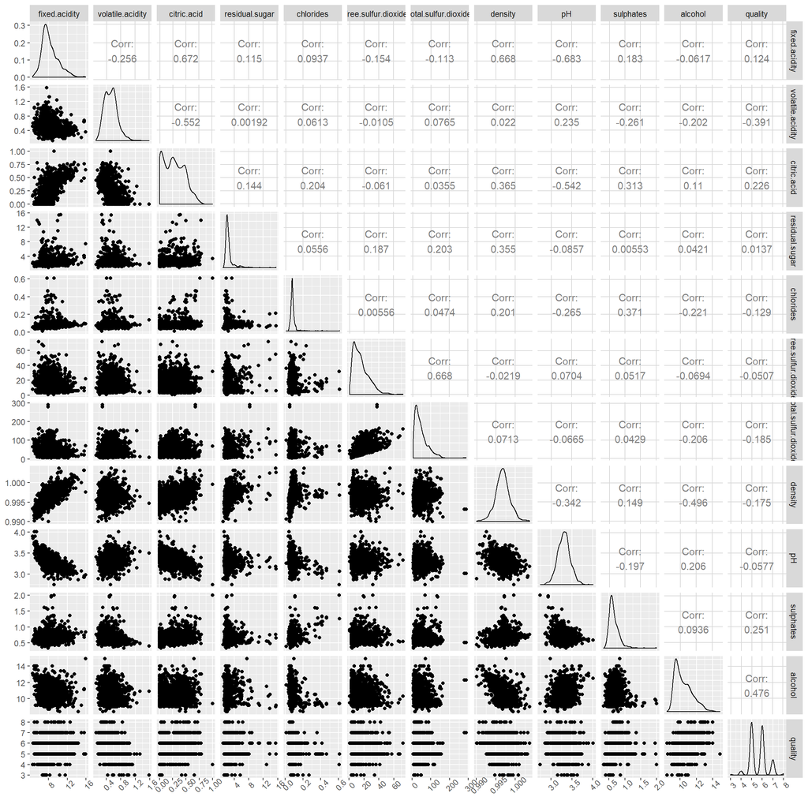

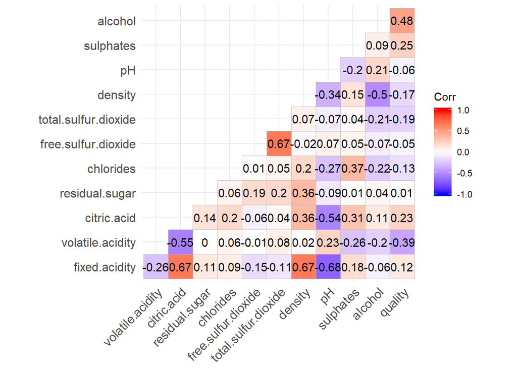

Vamos começar por analisar se existem correlações existentes entre as variáveis utilizando matrizes de correlação. Em termos de correlação com qualidade, as únicas variáveis que tem uma correlação mais relevante são *alcohol* (correlação positiva) e *volatile.acidity* (correlação negativa) e mesmo assim são correlações fracas. Há correlações mais fortes entre as outras características, como entre *density* e *fixed.acidity* e *pH* e as variáveis relacionadas à acidez (sendo uma correlação mais óbvia, já que quanto menor o pH é esperado um maior teor de acidez).

Isso não que dizer que as outras variáveis não tem influência sobre a qualidade, é possível que as correlações não sejam lineares.

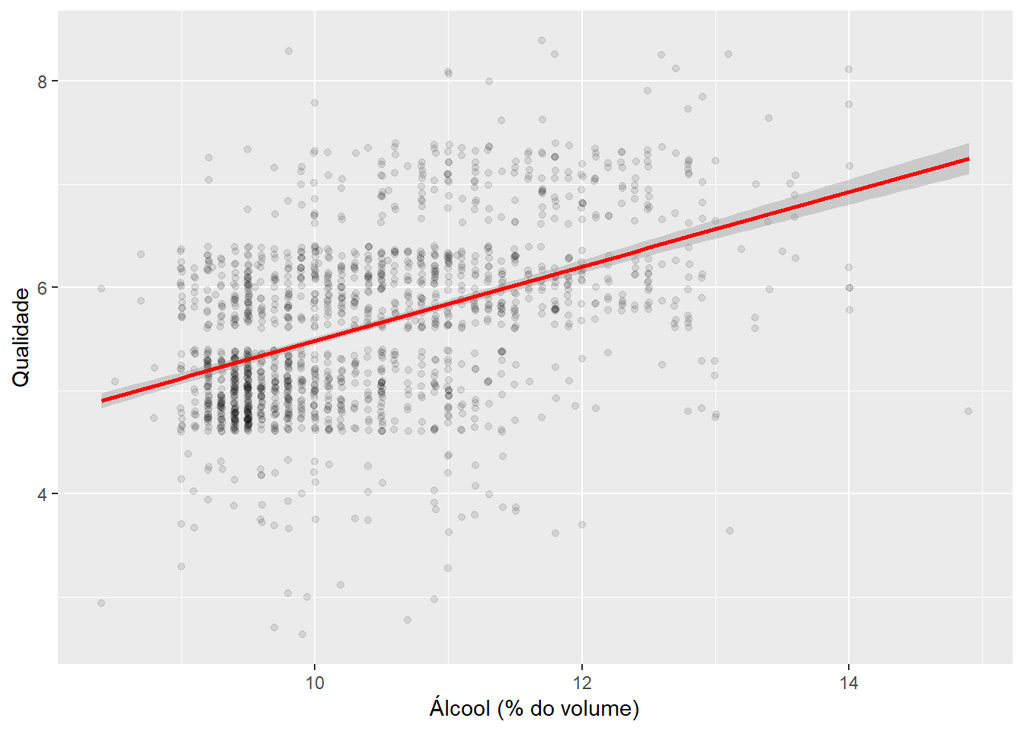

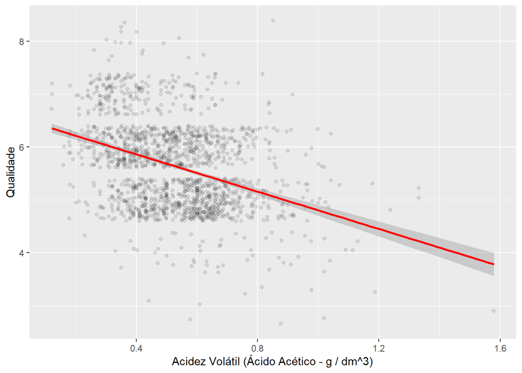

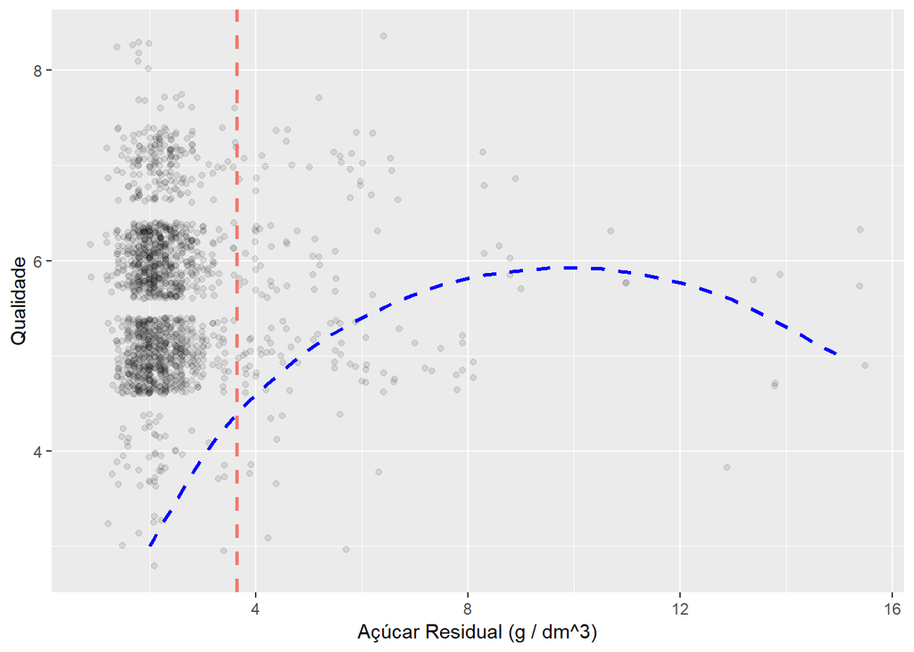

Observando o gráfico de dispersão entre a quantidade de açúcar e a qualidade, vemos que o que foi observado anteriormente no histograma de *residual.sugar* fica um pouco mais evidente, a linha vertical tracejada indica o limite onde a quantidade de açúcar é considerada um outlier dentre os vinhos observados, vinhos mais doces não são avaliados como de alta qualidade, mas é interessante notar uma certa curva (linha tracejada em azul) em que a qualidade sobe um pouco com o aumento do açúcar e depois desce quando esta quantidade é muito alta, demostrando uma correlação não-linear, porém, seria necessário obter mais amostras de vinhos com concentração mais alta de açúcar para comprovar está hipótese, já que a grande maioria nesta amostra possui concentrações mais baixas.

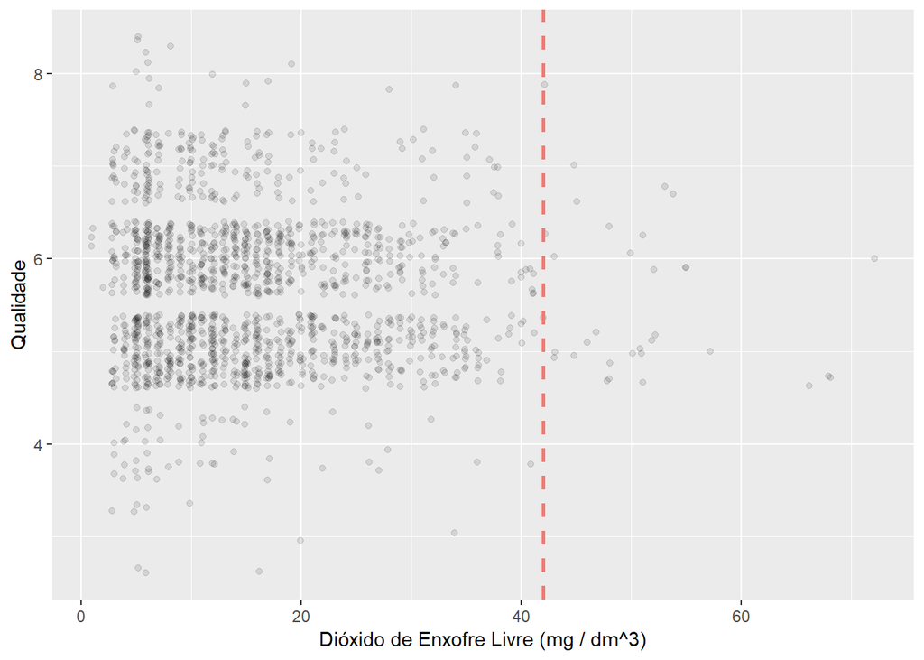

Observando a variável *free.sulfur.dioxide*, vemos que, quando em grande quantidade (novamente, a linha vermelha tracejada indica o limite onde a observação em considerada um outlier), a qualidade do vinho parece ser afetada.

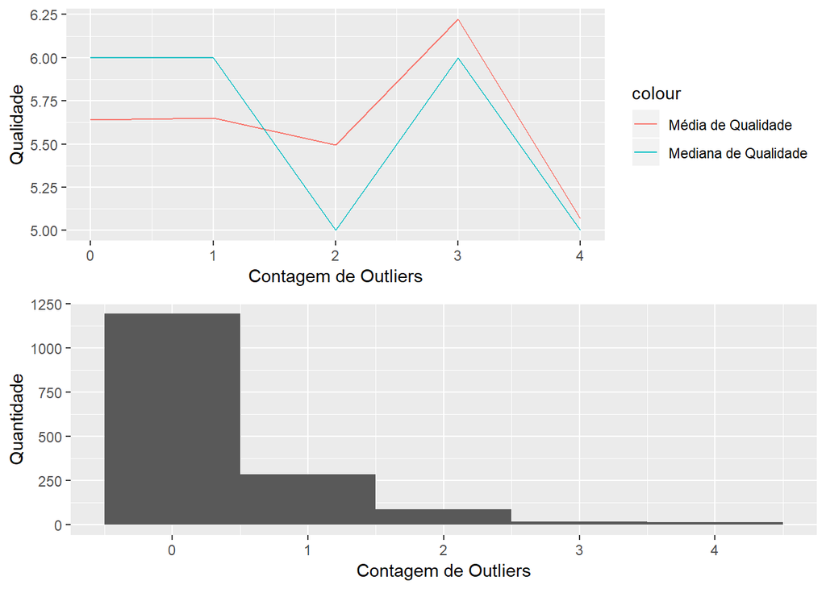

Por fim, vejamos se o vinho apresenta muitas variáveis com valores aberrantes impacta em sua nota final. Vemos um comportamento interessante. Entre 0 e 1 atributos outliers, a qualidade parece não variar muito, em 2, a nota cai consideravelmente, mas com 3, a nota aumenta, a média chega a ser maior quando possui 0 ou 1. E a nota cai mais uma vez quando há 4 variáveis aberrantes. E importante apenas resaltar que há poucas amostras com 3 e 4 variáveis aberrantes (como mostrado no segundo gráfico), então esta hipótese precisa ser testada com um número maior de amostras.

# Análise Bivariada

### Discuta sobre alguns dos relacionamentos observados nesta parte da investigação. Como os atributos de interesse variaram no conjunto de dados?

Foi possível observar a correlação entre a qualidade e os outros atributos do vinho. Os únicos com uma correlação mais forte foram *alcohol* e *volatile.acidity*. Outras correlações possíveis foram com *residual.sugar* e *free.sulfur.dioxide*, embora não sejam correlações lineares.

### Você observou algum relacionamento interessante entre os outros atributos (os que não são de interesse)?

Foi interessante observar como a quantidade de variáveis aberrantes parecem ter influência na qualidade, como descrito no início da análise, o equilíbrio entre as características é importante, mas estranhamente quando há 3 variáveis outliers a qualidade apresentou uma leve melhora.

### Qual foi o relacionamento mais forte encontrado?

O relacionamento mais forte foi com a variável *alcohol*.

# Seção de Gráficos Multivariados

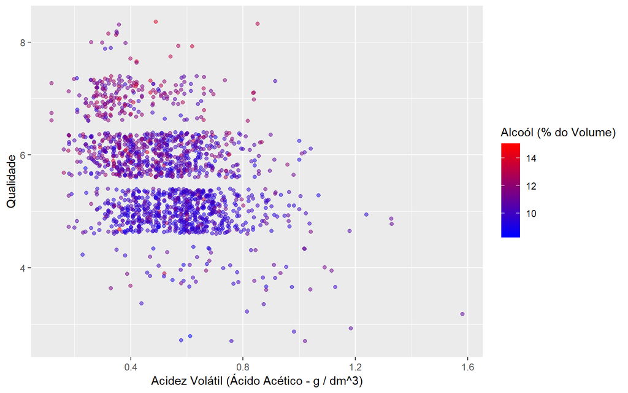

Neste gráfico, analisamos como é a relação entre teor alcoólico e a acidez volátil, o que vemos é uma certa convergência em que é mais predominante entre os vinhos de alta qualidade um teor alcoólico maior e com baixa acidez volátil.

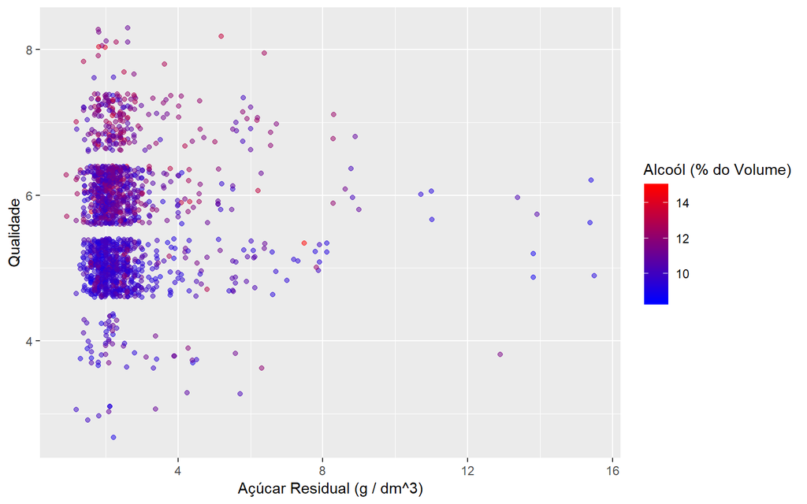

Isso se reforça ao observar a quantidade de açúcar residual e o teor alcoólico, vemos também que dentre os vinhos com melhor avaliação predominam os menos adocicados e com maior teor alcooólico. Mesmo os vinhos mais doces que estão mais acima no gráfico apresentam um teor alcoólico tendendo para o mais alto.

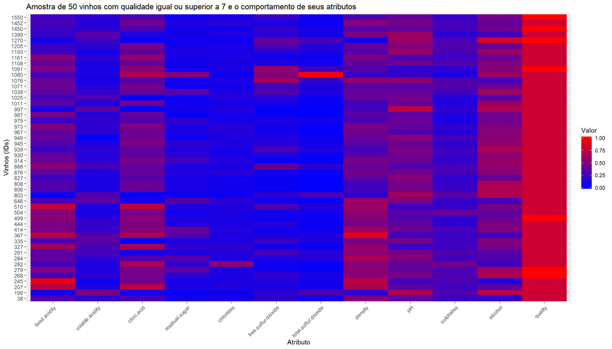

Finalmente, vemos um mapa de calor onde peguei uma amostra de 50 vinhos com qualidade maior ou igual à 7, cada linha representa um vinho e as colunas são as variáveis correspondentes às propriedades químicas juntamente com a variável correspondente à qualidade, as variáveis foram normalizadas utilizando a técnica *min-max normalization*. As células do mapa indicam quão alto é o valor da variável dentro de sua própria distribuição, ou seja, quanto mais vermelha, mais para a direita do histograma dessa varíavel e quanto mais azul, mais à esquerda.

Podemos ver que para as variáveis *alcohol*, *density* e *pH* predominam valores mais altos, enquanto *volatile.acidity*, *residual.sugar*, *chlorides*, *total.sulfur.dioxide* e *free.sulfur.dioxide* tem prevalência de valores mais baixos, as outras variáveis apresentam uma variação mais regular.

Com base nessa amostra, vemos que vinhos com maior teor alcoólico, menos ácidos e menos doces tendem a ter uma avaliação de qualidade maior.

# Análise Multivariada

### Discuta sobre os relacionamentos observados nesta parte da investigação. Quais atributos que fortaleceram os demais na observação das variáveis de interesse?

Os gráficos gerados reforçam a importância do teor alcoólico e da acidez volátil, vimos, por exemplo, que em vinhos com baixa concentração de açúcar a maoria dos que possuem uma avaliação melhor também tendem a ter um teor alcoólico mais alto.

### Interações surpreendentes e/ou interessantes foram encontradas entre os atributos?

Vinhos com maior teor alcoólico, menos ácidos e menos doces tendem a ter uma avaliação de qualidade maior.

### OPCIONAL: Modelos foram criados usando este conjunto de dados? Discuta sobre os pontos fortes e as limitações do seu modelo.

Não foram criados modelos.

# Gráficos Finais e Sumário

### Primeiro Gráfico

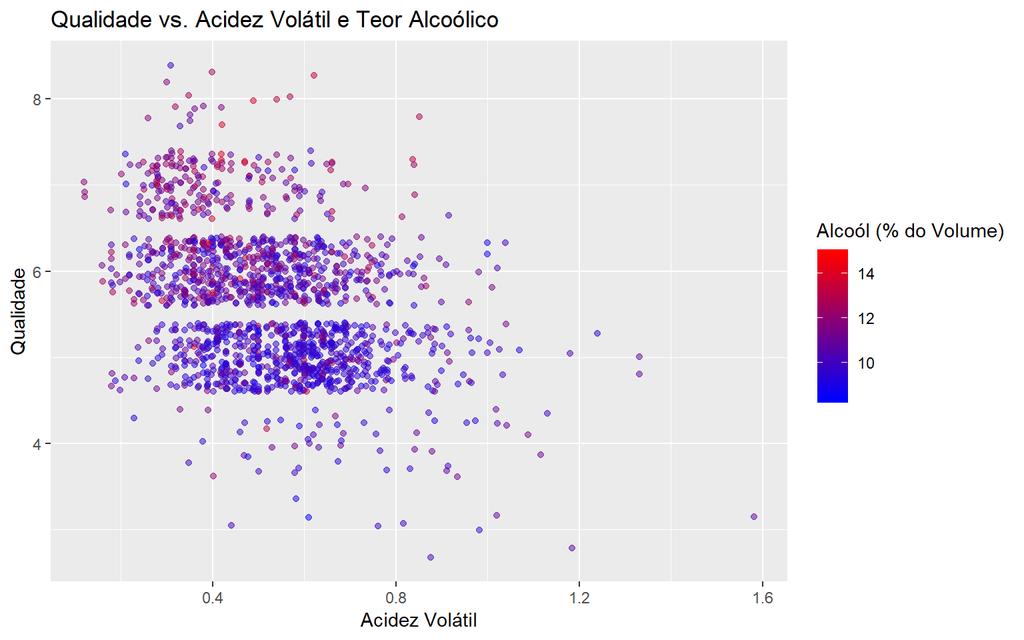

### Descrição do Primeiro Gráfico

Este gráfico demostra a correlação existente entre a qualidade do vinho e seu teor alcoólico e acidez volátil. Nele é possível ver como um teor alcoólico mais alto e baixa acidez volátil contribuem para vinhos melhores avaliados.

### Segundo Gráfico

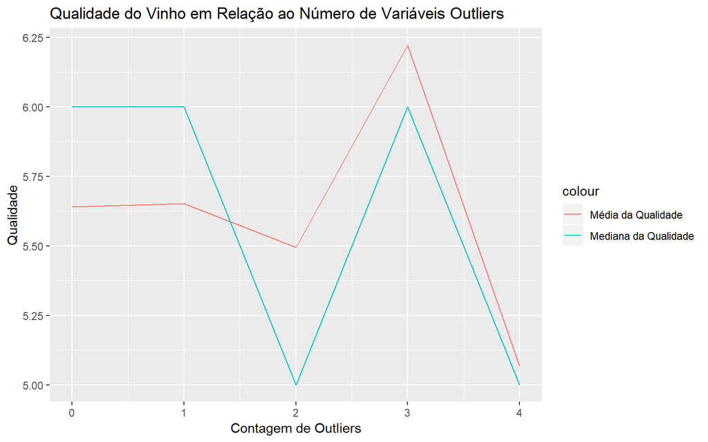

### Descrição do Segundo Gráfico

O equilíbrio entre os atributos de um vinho aparenta ser importante para determinar sua qualidade. No gráfico acima, verifiquei a média e a mediana da qualidade de acordo com o número de atributos considerados aberrantes entre os 1599 vinhos analisador. Entre 0 e 1 atributos outliers, a qualidade parece não variar muito, em 2, a nota cai consideravelmente, mas com 3, a nota aumenta, a média chega a ser maior quando possui 0 ou 1. E a nota cai mais uma vez quando há 4 variáveis aberrantes.

### Terceiro Gráfico

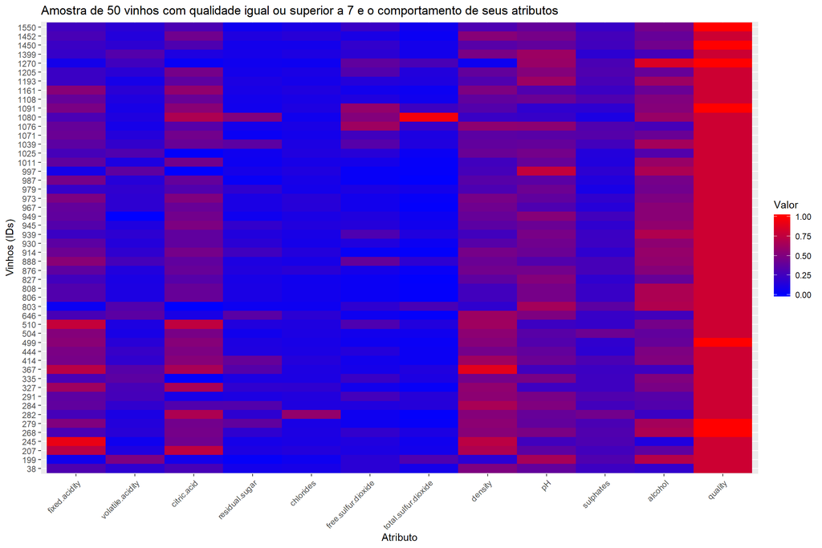

### Descrição do Terceiro Gráfico

Acima temos um mapa de calor onde peguei uma amostra de 50 vinhos com qualidade maior ou igual à 7, cada linha representa um vinho e as colunas são as variáveis correspondentes às propriedades químicas juntamente com a variável correspondente à qualidade, as variáveis foram normalizadas utilizando a técnica *min-max normalization*. As células do mapa indicam quão alto é o valor da variável dentro de sua própria distribuição, ou seja, quanto mais vermelha, mais para a direita do histograma dessa varíavel e quanto mais azul, mais à esquerda.

Podemos ver que para as variáveis *alcohol*, *density* e *pH* predominam valores mais altos, enquanto *volatile.acidity*, *residual.sugar*, *chlorides*, *total.sulfur.dioxide* e *free.sulfur.dioxide* tem prevalência de valores mais baixos, as outras variáveis apresentam uma variação mais regular.

Com base nessa amostra, vemos que vinhos com maior teor alcoólico, menos ácidos e menos doces tendem a ter uma avaliação de qualidade maior.

# Reflexão

O conjunto de dados analisado possui informações sobre 1599 vinhos tintos sendo classificados numa escala de qualidade que varia de 0 a 10 e medições sobre várias de suas propriedades químicas, como teor alcoólico, nível de açúcar, acidez, densidade, etc.

Comecei por analisar como as variáveis se comportavam no geral, observando suas distribuições e como elas interferem na qualidade do vinho. A qualidade, apesar da escala definida entre 0 e 10, variou na amostra entre 3 e 8 sendo que metade dos vinhos possui nota 6 ou superior.

As variáveis que apresentaram uma correlação mais fortes com a qualidade foram o teor alcoólico e o nível de acidez volátil, esta última, quando em altos níveis, contribui para um sabor desagradável de vinagre. O nível de açúcar aparenta uma correlação não-linear, em que até um certo nível a qualidade aumenta, mas quando o vinho é muito doce, a nota cai. Outra característica percebida foi o equilíbrio entre as características do vinho, se alguns atributos se sobressaem demais, isso afeta a qualidade, estranhamente quando há 3 atributos fora do normal a nota parece aumentar.

Seria interessante aprofundar o estudo com vinhos mais adocicados para validar se o padrão de curva observado em que o nível de açúcar, até um certo ponto, afeta positivamente a qualidade, mas afeta negativamente se a concentração for mais alta é verdadeiro ou foi apenas um acaso, já que haviam poucos vinhos na amostra com essas características e eles acabaram sendo identificado como outliers.